# fMRI analysis

## 9. 각 ROI 벡터 추출

```r
# 특정 ROI 벡터 추출 (Amigdala 예시 - 이름 확인 후 수정)
v_precentral_L <- df_roi$Precentral_L
length(v_precentral_L)
```

```
[1] 187
```

```r
# [1] 187

head(v_precentral_L)
```

```
[1]  0.002466648  0.003907635 -0.007684601 -0.012189583  0.025463361
[6] -0.012794315
```

```r
# 예: [1] -0.612 -0.493  0.039 -0.187 -0.381  0.349  ← 첫 6개 BOLD

v_precentral_R <- df_roi$Precentral_R
head(v_precentral_R)
```

```
[1] -0.045678951 -0.029651754  0.021387718 -0.006788219  0.025921438
[6]  0.029091787
```

```r
v_frontal_sup_L <- df_roi$Frontal_Sup_2_L
head(v_frontal_sup_L)
```

```
[1]  0.017123661 -0.002048301 -0.024731835  0.014374460  0.023877359
[6] -0.017678234
```

```r
# 여러 ROI 한번에
roi_vectors <- list(
  Precentral_L = df_roi$Precentral_L,
  Precentral_R = df_roi$Precentral_R,
  Frontal_Sup_2_L = df_roi$Frontal_Sup_2_L,
  Frontal_Sup_2_R = df_roi$Frontal_Sup_2_R,
  Frontal_Mid_2_L = df_roi$Frontal_Mid_2_L
)

lapply(roi_vectors, head)  # 모든 ROI 첫 6개 확인
```

```
$Precentral_L
[1]  0.002466648  0.003907635 -0.007684601 -0.012189583  0.025463361
[6] -0.012794315

$Precentral_R
[1] -0.045678951 -0.029651754  0.021387718 -0.006788219  0.025921438
[6]  0.029091787

$Frontal_Sup_2_L
[1]  0.017123661 -0.002048301 -0.024731835  0.014374460  0.023877359
[6] -0.017678234

$Frontal_Sup_2_R
[1]  0.008415814 -0.002569649 -0.005317645 -0.030543712  0.008661599
[6] -0.020352199

$Frontal_Mid_2_L
[1]  0.0034972819  0.0006688882  0.0239479243  0.0216765789 -0.0024160167
[6] -0.0050136920
```

## 10. ROI timeseries 시각화

```r
# ROI 데이터 (지정된 5개)
roi_names <- c("Precentral_L", "Precentral_R", "Frontal_Sup_2_L",
               "Frontal_Sup_2_R", "Frontal_Mid_2_L")
roi_data <- df_roi[roi_names]

#
png("frontal_roi_exact.png", width=900, height=600, res=100)

par(mar=c(5, 4.2, 3, 2))  # 표준 마진

# 첫 번째 ROI 실선
plot(roi_data$Precentral_L, type="l", lwd=2.2, col="black",
     xlab="Time (TR)", ylab="Mean BOLD",
     main="Frontal ROIs BOLD Time Series")

# 나머지 4개 ROI 점선
lines(roi_data$Precentral_R, lty=2, lwd=1.8)
lines(roi_data$Frontal_Sup_2_L, lty=2, lwd=1.8)
lines(roi_data$Frontal_Sup_2_R, lty=2, lwd=1.8)
lines(roi_data$Frontal_Mid_2_L, lty=2, lwd=1.8)

# 범례
legend("topright", roi_names, cex=0.82, pt.cex=1.1,
       lty=c(1,2,2,2,2), lwd=c(2.2,1.8,1.8,1.8,1.8))

dev.off()
```

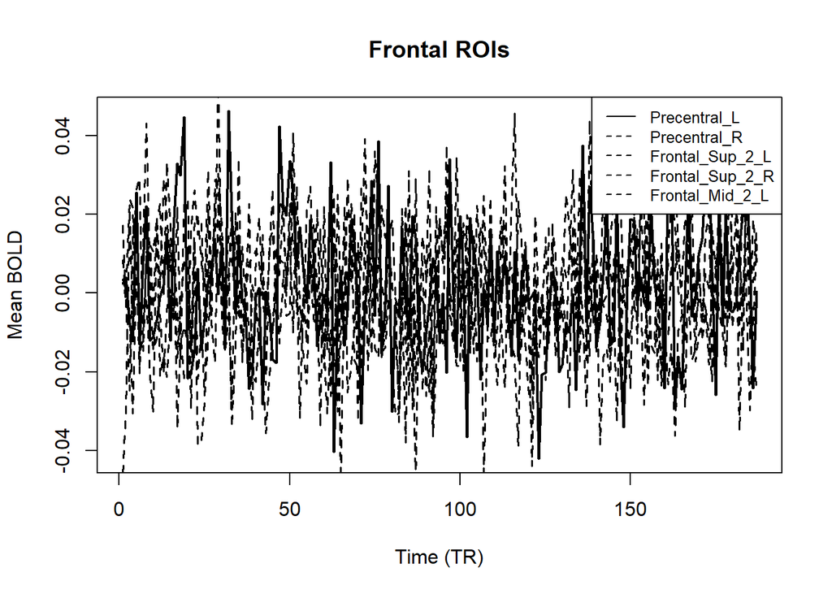

```r
# 플롯
plot(roi_data$Precentral_L, type="l", lwd=2.2, col="black",
     xlab="Time (TR)", ylab="Mean BOLD", main="Frontal ROIs")
lines(roi_data$Precentral_R, lty=2, lwd=1.8)
lines(roi_data$Frontal_Sup_2_L, lty=2, lwd=1.8)
lines(roi_data$Frontal_Sup_2_R, lty=2, lwd=1.8)
lines(roi_data$Frontal_Mid_2_L, lty=2, lwd=1.8)
legend("topright", roi_names, cex=0.82, lty=c(1,2,2,2,2))
```

## 11. 상관계수 & FC 설명

상관계수, FC란?  
상관계수: 두 ROI BOLD가 얼마나 비슷하게 움직이는지 (-1~1)

상관관계: 두 변수가 얼마나 관계성이 있는지. 즉, x가 증가하면 y값은 증가하나 감소하나 증가: 양의 상관관계 감소: 음의 상관관계 상관계수: 상관관계를 나타내는 수 상관계수 범위: -1<= r <=1 FC(functional connectivity): 해부학적으로 연결되어 있는지 여부와 상관없이 기능적으로 함께 작동하는 정도.  
기능적 연결 강도. FC의 가장 대표적인 계산방법이 상관계수 ex) 편도체와 전전두엽의 BOLD 값이 비슷하게 증가하거나 감소한다 FC를 시각화하는 예시에는 Heatmap, correlation matrix, network graph가 있음

```r
# 5개 Frontal ROI만 선택 (roi_data 사용)
frontal_roi_names <- c("Precentral_L", "Precentral_R", "Frontal_Sup_2_L",
                       "Frontal_Sup_2_R", "Frontal_Mid_2_L")
frontal_roi_data <- roi_data[frontal_roi_names]  # 187 x 5

# 상관계수 행렬 계산 (5x5)
cor_mat_frontal <- cor(frontal_roi_data, use="pairwise.complete.obs", method="pearson")
dim(cor_mat_frontal)
```

```
[1] 5 5
```

```r
# [1] 5 5

# 값 확인
round(cor_mat_frontal, 2)
```

```
                Precentral_L Precentral_R Frontal_Sup_2_L Frontal_Sup_2_R
Precentral_L            1.00         0.00            0.05            0.09
Precentral_R            0.00         1.00           -0.09            0.00
Frontal_Sup_2_L         0.05        -0.09            1.00            0.00
Frontal_Sup_2_R         0.09         0.00            0.00            1.00
Frontal_Mid_2_L         0.16         0.10            0.00            0.05
                Frontal_Mid_2_L
Precentral_L               0.16
Precentral_R               0.10
Frontal_Sup_2_L            0.00
Frontal_Sup_2_R            0.05
Frontal_Mid_2_L            1.00
```

## 12. Heatmap 시각화 (**전체 AAL3 166x166 Heatmap**)

```r
# 전체 roi_ts 사용 (166 ROI)
cor_mat <- cor(roi_ts, use="pairwise.complete.obs", method="pearson")
dim(cor_mat)
```

```
[1] 166 166
```

```r
# [1] 166 166

# 컬러: 파랑-흰-빨강
col_pal <- colorRampPalette(c("blue", "white", "red"))(100)

# heatmap (166x166)
png("aal3_full_cor_matrix.png", width=1400, height=1200, res=120)

heatmap(cor_mat,
        symm=TRUE,
        col=col_pal,
        scale="none",
        margins=c(6,6),
        cexRow=0.6, cexCol=0.6,
        main="ROI-ROI Correlation Matrix (AAL3)",
        xlab="ROI", ylab="ROI")

dev.off()
```

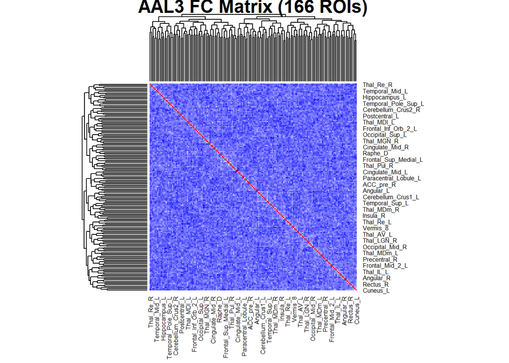

```r
heatmap(cor_mat, symm=TRUE, col=col_pal, scale="none",
        margins=c(6,6), cexRow=0.6, cexCol=0.6,
        main="AAL3 FC Matrix (166 ROIs)")
```

label: 복셀에 부여된 숫자  
숫자가 같으면 같은 뇌영역을 의미함

AAL3 atlas: https://doi.org/10.1016/j.neuroimage.2019.116189